# Data Science Salary Prediction (Final Project Summary)

TEAM 3 - Jeongmin An, Yeobi Hobson, Sameer Batra, Aditi Shukla

April 28, 2025

# **Data Science Salary Prediction (2020-2024)**

#### *Exploring salary evolution and predictive modeling in data science*

## **Table of Contents**

- 1. Abstract
- 2. Introduction
- 3. Previous Work(midterm)
- 4. Data Preprocessing for Modeling (Final part)
- 5. Regression Models for Salary Prediction
- 6. Classification Models for Income Categories
- 7. Conclusion
- 8. References

# **1. Abstract**

Building upon the findings from the midterm analysis, this project extends the exploration of salary trends in the data science field by focusing on advanced modeling techniques. After completing initial data cleaning, exploratory analysis, and statistical testing on a Kaggle-sourced dataset containing over 6,000 records(midterm analysis), this phase concentrates on predictive modeling and classification. We applied Linear Regression, Random Forest Regression, and XGBoost Regression to forecast salaries, followed by converting salary values into income categories based on U.S. Bureau of Labor Statistics standards. Using models such as Multinomial Logistic Regression, Random Forest Classification, XGBoost Classification, Naive Bayes, and Support Vector Machine (SVM), we classified salary ranges and evaluated model performance. Among the classification models, SVC and Random Forest achieved the highest accuracy.

# **2. Introduction**

The field of data science has experienced rapid growth over the last decade, emerging as one of the most in-demand and dynamic career paths across various industries. Organizations increasingly depend on data scientists to interpret complex datasets, optimize decision-making, and drive innovation. As a result, the demand for skilled data professionals continues to accelerate, with a corresponding impact on salary structures and career progression opportunities.

According to the U.S. Bureau of Labor Statistics (BLS), employment of data scientists is projected to grow by 36% from 2021 to 2031, far exceeding the average growth rate across all occupations. Numerous career rankings, such as those published by Glassdoor and LinkedIn, consistently place data science roles among the top jobs based on salary, job satisfaction, and career prospects. Despite this growing demand, salary distributions within data science are highly variable, influenced by multiple factors including experience level, job title, work model (remote, hybrid, on-site), and company size.

Understanding salary trends and developing predictive models for compensation is critical for a range of stakeholders. Data scientists and aspiring professionals can use salary insights to guide career decisions, salary negotiations, and education planning. Employers can leverage predictive analytics to inform recruitment strategies, compensation benchmarks, and retention initiatives. Academic institutions and policymakers can use these findings to align educational programs with labor market trends.

The objective of this project is twofold. First, we perform exploratory data analysis (EDA) to investigate how salaries have evolved from 2020 to 2024 and to identify the most influential factors driving salary differences. Second, we construct predictive models to estimate salaries based on structured variables such as experience level, company size, employment type, and job title.

## 2.1 SMART Research Questions

1. **S**pecific: Focuses on predicting 2025 salaries using four key features in the data science field.
2. **M**easurable: Model accuracy will be assessed using R², RMSE, and MAE in R.
3. **A**chievable: Historical data and R packages like tidymodels, ggplot2, and lm make this feasible.
4. **R**elevant: Addresses real-world salary forecasting needs for professionals and employers.
5. **T**ime-bound: Uses data from 2020–2024 to make predictions specifically for 2025

We utilize a publicly available dataset from Kaggle, comprising 6,599 observations spanning the years 2020 to 2024. To maintain consistency in salary comparisons and minimize variability from international factors such as currency exchange rates and cost-of-living differences, we restrict our analysis to employees based in the United States.

Through a combination of descriptive analysis, statistical testing, and machine learning modeling, this project aims to contribute insights into salary trends within the data science profession and evaluate the practical reliability of predictive models for salary estimation.

# **3. Previous Work(Midterm)**

## 3.1 Loading Dataset

The dataset used for this project was sourced from Kaggle’s publicly available *Data Science Salaries Dataset*. It initially contained 6,599 observations covering five years (2020–2024) and spanned a broad range of job titles and employment models across different countries.

Before performing exploratory analysis and modeling, we conducted a thorough data cleaning process to ensure quality, consistency, and relevance for our salary prediction objectives.

We first loaded the dataset into R using the `read.csv()` function and conducted basic inspections such as `head()`, `str()`, and `summary()` to familiarize ourselves with the data structure, variable types, and initial distributions.

## 3.2 Cleaning Dataset

### 3.2.1 Basic Inspections

Basic inspections were conducted to verify:

- Presence of missing data
- Variable types (factors, integers, characters)
- Overall structure of the dataset

```
## Total missing values: 0
```

```
##          job_title   experience_level    employment_type        work_models
##                  0                  0                  0                  0
##          work_year employee_residence             salary    salary_currency
##                  0                  0                  0                  0
##      salary_in_usd   company_location       company_size
##                  0                  0                  0
```

```
##        job_title experience_level employment_type work_models work_year
## 1  Data Engineer        Mid-level       Full-time      Remote      2024
## 2  Data Engineer        Mid-level       Full-time      Remote      2024
## 3 Data Scientist     Senior-level       Full-time      Remote      2024
## 4 Data Scientist     Senior-level       Full-time      Remote      2024
## 5   BI Developer        Mid-level       Full-time     On-site      2024
## 6   BI Developer        Mid-level       Full-time     On-site      2024
##   employee_residence salary salary_currency salary_in_usd company_location
## 1      United States 148100             USD        148100    United States
## 2      United States  98700             USD         98700    United States
## 3      United States 140032             USD        140032    United States
## 4      United States 100022             USD        100022    United States
## 5      United States 120000             USD        120000    United States
## 6      United States  62100             USD         62100    United States
##   company_size
## 1       Medium
## 2       Medium
## 3       Medium
## 4       Medium
## 5       Medium
## 6       Medium
```

```r
str(salaries)
```

```
## 'data.frame':    6599 obs. of  11 variables:
##  $ job_title         : chr  "Data Engineer" "Data Engineer" "Data Scientist" "Data Scientist" ...
##  $ experience_level  : chr  "Mid-level" "Mid-level" "Senior-level" "Senior-level" ...
##  $ employment_type   : chr  "Full-time" "Full-time" "Full-time" "Full-time" ...
##  $ work_models       : chr  "Remote" "Remote" "Remote" "Remote" ...
##  $ work_year         : int  2024 2024 2024 2024 2024 2024 2024 2024 2024 2024 ...
##  $ employee_residence: chr  "United States" "United States" "United States" "United States" ...
##  $ salary            : int  148100 98700 140032 100022 120000 62100 250000 150000 219650 136000 ...
##  $ salary_currency   : chr  "USD" "USD" "USD" "USD" ...
##  $ salary_in_usd     : int  148100 98700 140032 100022 120000 62100 250000 150000 219650 136000 ...
##  $ company_location  : chr  "United States" "United States" "United States" "United States" ...
##  $ company_size      : chr  "Medium" "Medium" "Medium" "Medium" ...
```

```r
summary(salaries)
```

```
##   job_title         experience_level   employment_type    work_models
##  Length:6599        Length:6599        Length:6599        Length:6599
##  Class :character   Class :character   Class :character   Class :character
##  Mode  :character   Mode  :character   Mode  :character   Mode  :character
##
##
##
##    work_year    employee_residence     salary         salary_currency
##  Min.   :2020   Length:6599        Min.   :   14000   Length:6599
##  1st Qu.:2023   Class :character   1st Qu.:   96000   Class :character
##  Median :2023   Mode  :character   Median :  140000   Mode  :character
##  Mean   :2023                      Mean   :  179283
##  3rd Qu.:2023                      3rd Qu.:  187500
##  Max.   :2024                      Max.   :30400000
##  salary_in_usd    company_location   company_size
##  Min.   : 15000   Length:6599        Length:6599
##  1st Qu.: 95000   Class :character   Class :character
##  Median :138666   Mode  :character   Mode  :character
##  Mean   :145561
##  3rd Qu.:185000
##  Max.   :750000
```

**Result:**  
- No missing values were detected (`colSums(is.na())` returned 0 for all columns). - Variables included `job_title`, `experience_level`, `employment_type`, `work_models`, `company_size`, `work_year`, `salary_in_usd`, `salary_currency`, and `employee_residence`.

### 3.2.2 Data Filtering: U.S.-Based Employees Only

#### Check employee residence distribution

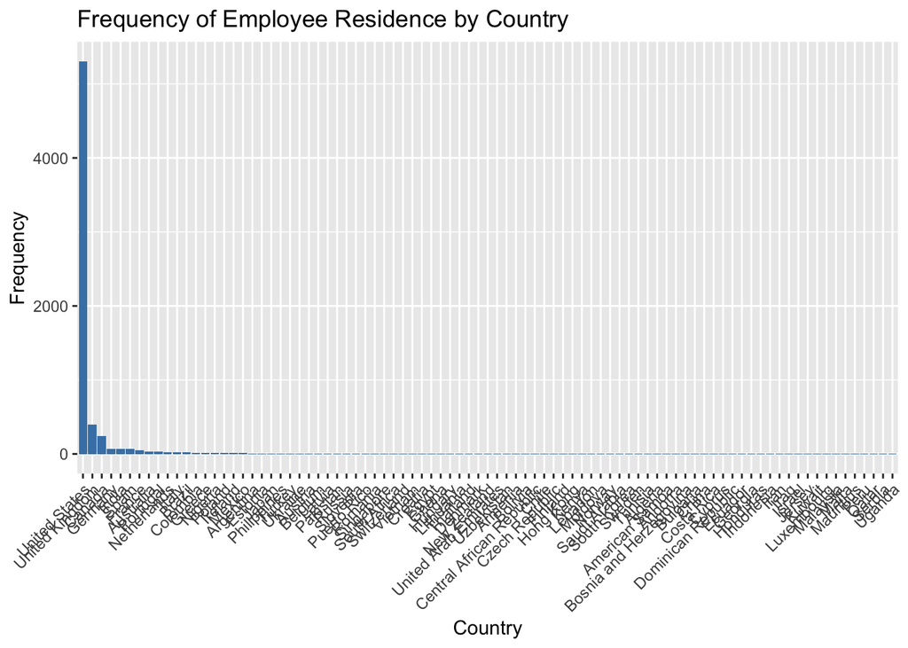

#### Data Filtering & Remove unnecessary columns

```
##        job_title experience_level employment_type work_models work_year
## 1  Data Engineer        Mid-level       Full-time      Remote      2024
## 2  Data Engineer        Mid-level       Full-time      Remote      2024
## 3 Data Scientist     Senior-level       Full-time      Remote      2024
## 4 Data Scientist     Senior-level       Full-time      Remote      2024
## 5   BI Developer        Mid-level       Full-time     On-site      2024
## 6   BI Developer        Mid-level       Full-time     On-site      2024
##   salary_in_usd company_location company_size
## 1        148100    United States       Medium
## 2         98700    United States       Medium
## 3        140032    United States       Medium
## 4        100022    United States       Medium
## 5        120000    United States       Medium
## 6         62100    United States       Medium
```

We filtered the dataset to retain only U.S.-based employees to ensure salary comparability and minimize exchange rate effects.

### 3.2.3 Outlier Detection and Removal

To minimize the influence of extreme salary outliers, we used the Interquartile Range (IQR) method:

#### Detect outliers

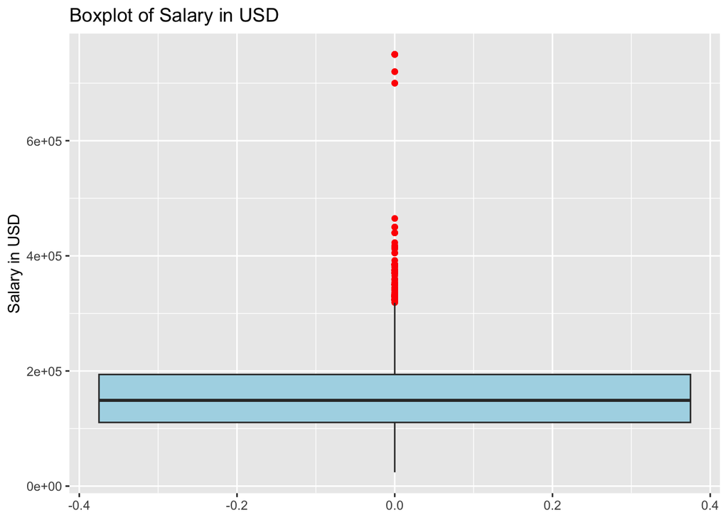

#### Remove outliers

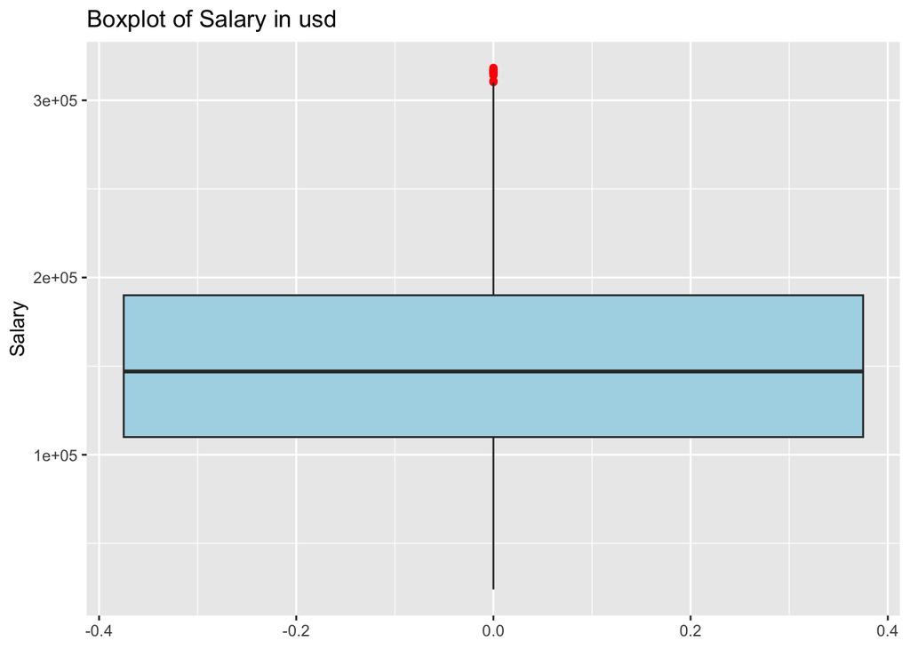

- Approximately 101 outliers were removed.
- Final dataset size after outlier removal: **5,204 observations**.

#### Detecting Outliers Using the ezids package

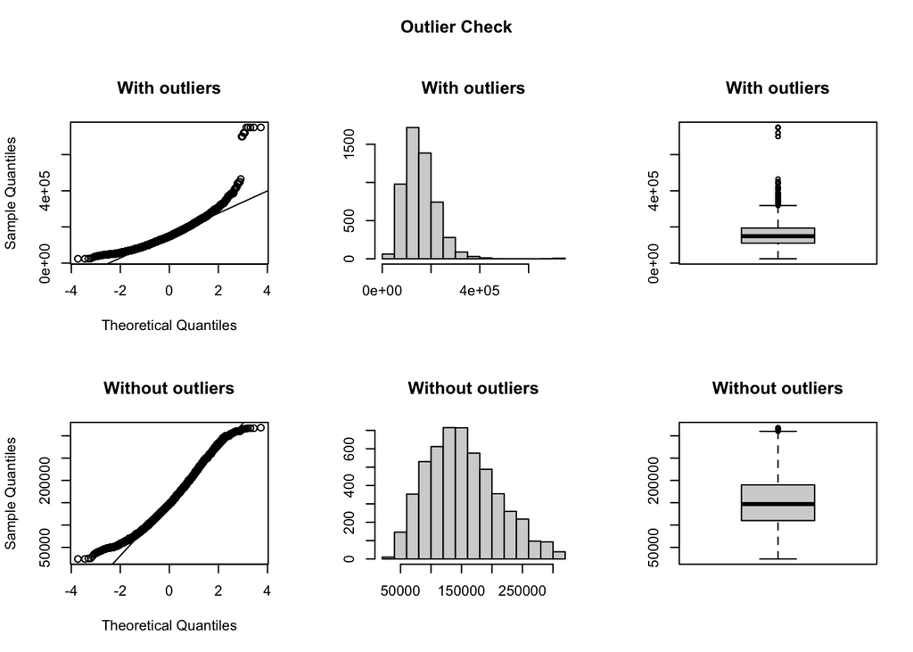

```
## Outliers identified: 101
## Proportion (%) of outliers: 1.9
## Mean of the outliers: 392733
## Mean without removing outliers: 157780.9
## Mean if we remove outliers: 153221
## Outliers successfully removed
```

[figure not shown]

## 3.3. Exploratory Data Analysis (EDA)

The goal of Exploratory Data Analysis (EDA) was to identify underlying patterns, detect anomalies, and explore relationships among variables before proceeding to formal modeling. In this section, we systematically examine how salary in data science roles is associated with various factors, including work year, experience level, work model, company size, and job title.

### 3.3.1 Salary Trends by Year

We analyzed the average salary by work year (2020–2024).

```
## [1] 2024 2023 2022 2021 2020
```

```
## # A tibble: 5 × 3
##   work_year Avg_Salary_USD Count
##       <int>          <dbl> <int>
## 1      2020        132342     25
## 2      2021        141220.    86
## 3      2022        147344.   822
## 4      2023        155624.  3784
## 5      2024        147658.   487
```

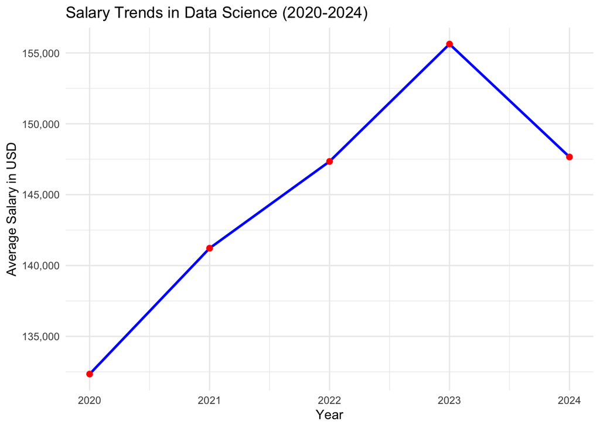

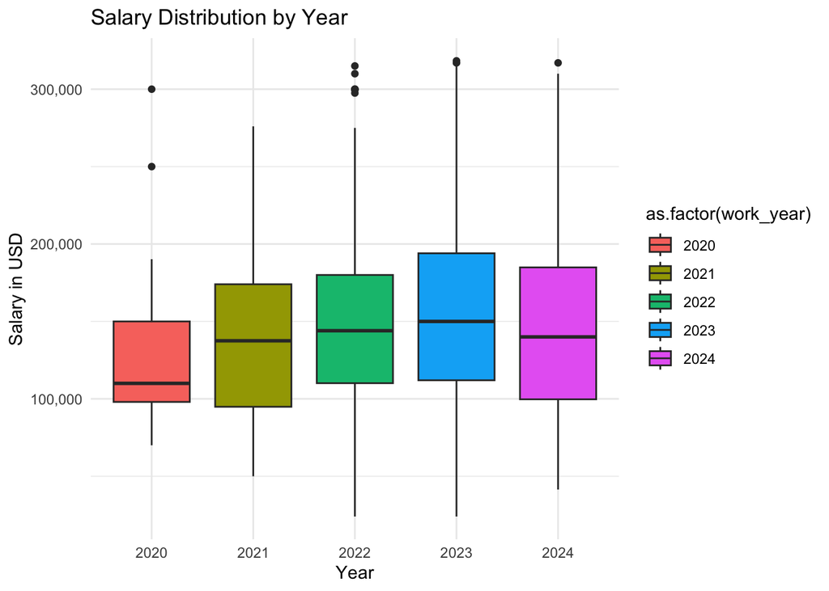

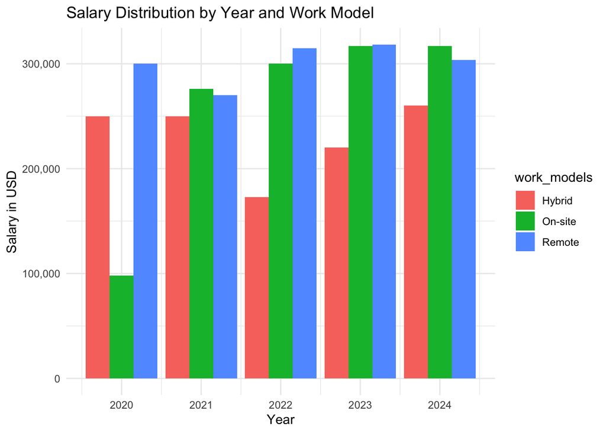

Key findings: - A steady upward salary trend was observed from 2020 to 2023. - The peak average salary occurred in **2023**, around **$156,000**. - A slight decrease was observed in **2024**.

A one-way ANOVA test showed significant differences across years:

```
##                        Df    Sum Sq   Mean Sq F value   Pr(>F)
## as.factor(work_year)    4 8.859e+10 2.215e+10   6.716 2.18e-05 ***
## Residuals            5199 1.715e+13 3.298e+09
## ---
## Signif. codes:  0 '***' 0.001 '**' 0.01 '*' 0.05 '.' 0.1 ' ' 1
```

Result:  
- F-statistic = **6.716**, p-value = **2.18e-05** (highly significant)

### 3.3.2 Salary by Experience Level

We examined salary differences across experience levels: Entry-level, Mid-level, Senior-level, and Executive-level.

```
## [1] "Mid-level"       "Senior-level"    "Entry-level"     "Executive-level"
```

```
## # A tibble: 4 × 3
##   experience_level Avg_Salary_USD Count
##   <chr>                     <dbl> <int>
## 1 Entry-level             101236.   361
## 2 Executive-level         186557.   201
## 3 Mid-level               131124.  1153
## 4 Senior-level            163981.  3489
```

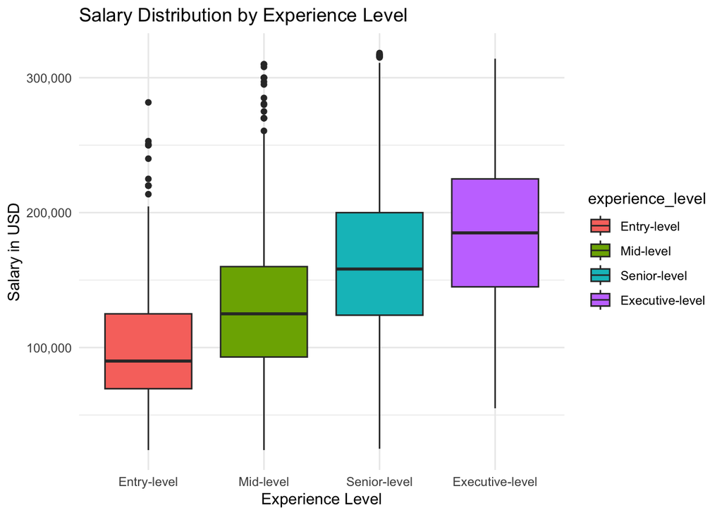

Key findings: - Salaries rise sharply with increasing experience. - Executive-level roles had salaries exceeding **$250,000**.

ANOVA results confirmed significant salary differences:

```
##                    Df    Sum Sq   Mean Sq F value Pr(>F)
## experience_level    3 2.166e+12 7.220e+11   249.2 <2e-16 ***
## Residuals        5200 1.507e+13 2.898e+09
## ---
## Signif. codes:  0 '***' 0.001 '**' 0.01 '*' 0.05 '.' 0.1 ' ' 1
```

Result:  
- F-statistic = **249.2**, p-value < **2e-16** (extremely significant)

### 3.3.3 Salary by Work Model

We compared salaries across work models: Remote, On-site, and Hybrid.

```
## [1] "Remote"  "On-site" "Hybrid"
```

```
## # A tibble: 3 × 3
##   work_models Avg_Salary_USD Count
##   <chr>                <dbl> <int>
## 1 Hybrid             128468.    40
## 2 On-site            154398.  3200
## 3 Remote             151807.  1964
```

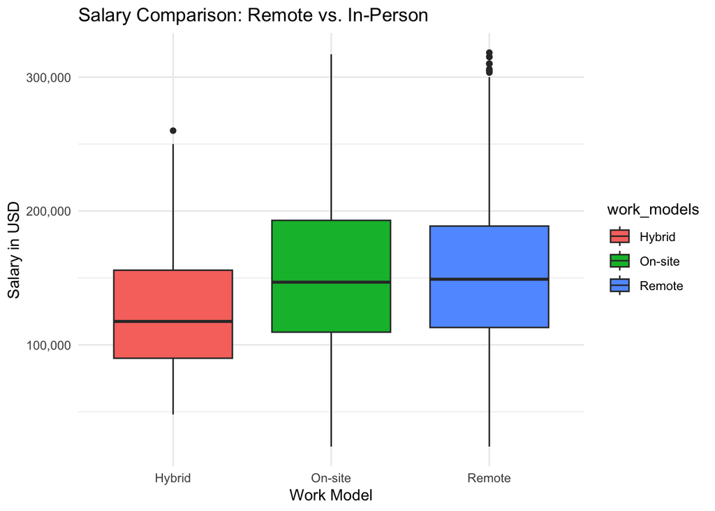

ANOVA results:

```
##               Df    Sum Sq   Mean Sq F value  Pr(>F)
## work_models    2 3.287e+10 1.643e+10   4.969 0.00698 **
## Residuals   5201 1.720e+13 3.307e+09
## ---
## Signif. codes:  0 '***' 0.001 '**' 0.01 '*' 0.05 '.' 0.1 ' ' 1
```

Result:  
- F-statistic = **4.969**, p-value = **0.00698** (statistically significant)

### 3.3.4 Salary by Company Size

We also explored salary differences by company size (Small, Medium, Large).

```
## [1] "Medium" "Large"  "Small"
```

```
## # A tibble: 3 × 4
##   company_size mean_salary median_salary count
##   <chr>              <dbl>         <dbl> <int>
## 1 Large            152726.        145000   311
## 2 Medium           153590.        147200  4843
## 3 Small            120570.        112500    50
```

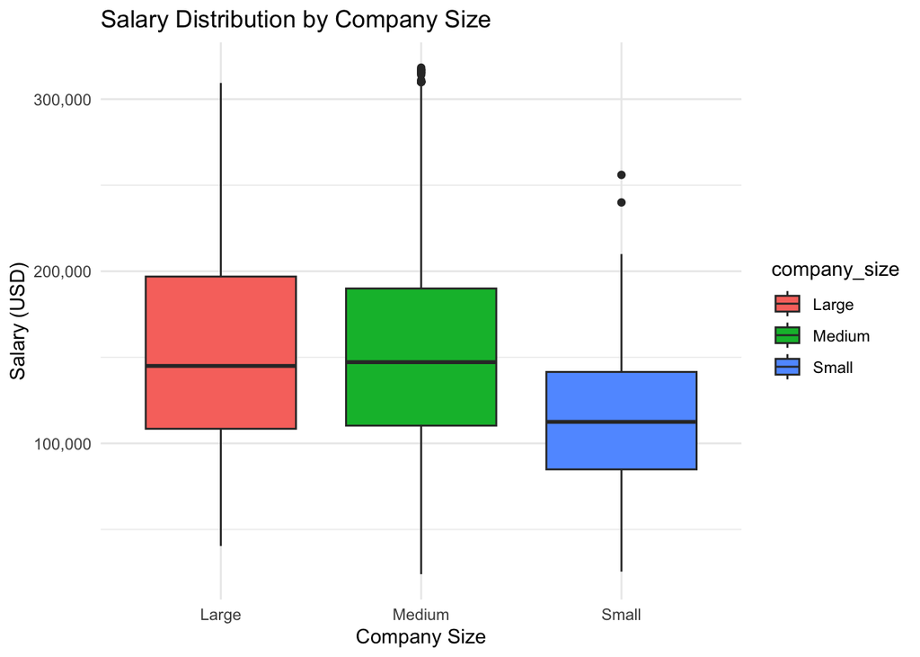

Key findings: - Larger companies tend to offer higher salaries compared to smaller firms.

```
##                Df    Sum Sq   Mean Sq F value   Pr(>F)
## company_size    2 5.404e+10 2.702e+10    8.18 0.000284 ***
## Residuals    5201 1.718e+13 3.303e+09
## ---
## Signif. codes:  0 '***' 0.001 '**' 0.01 '*' 0.05 '.' 0.1 ' ' 1
```

Result:  
- F-statistic = **8.18**, p-value = **0.000284**

### 3.3.5 Top Salary by Job Title in 2024

```
## # A tibble: 35 × 4
##    job_title                      mean_salary max_salary count
##    <chr>                                <dbl>      <int> <int>
##  1 Managing Director Data Science     260000      260000     1
##  2 AI Architect                       229662.     317000     4
##  3 Data Product Manager               213150      227200     2
##  4 Computer Vision Engineer           210000      235000     2
##  5 Director of Data Science           202500      225000     2
##  6 Applied Scientist                  195279.     260000     7
##  7 Data Science Engineer              190000      245000     2
##  8 Machine Learning Engineer          187610.     303400    55
##  9 Machine Learning Scientist         186500      252000     3
## 10 Research Engineer                  179242.     295000    17
## # ℹ 25 more rows
```

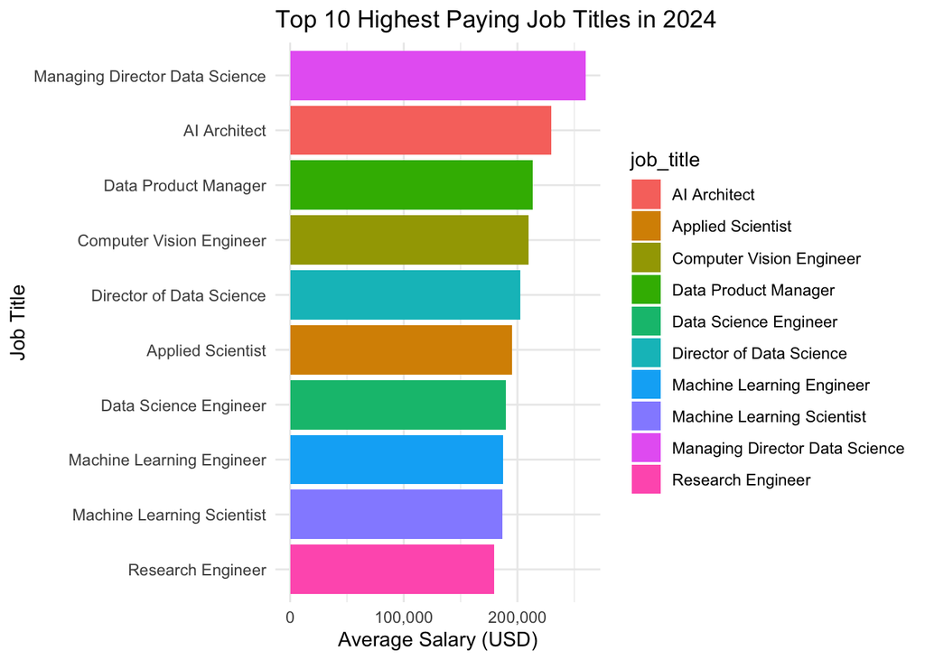

```
##      job_title experience_level employment_type work_models work_year
## 1 AI Architect     Senior-level       Full-time     On-site      2024
##   salary_in_usd company_location company_size
## 1        317000    United States       Medium
```

### 3.3.6 Most Common Job Title

#### Filter data by job title

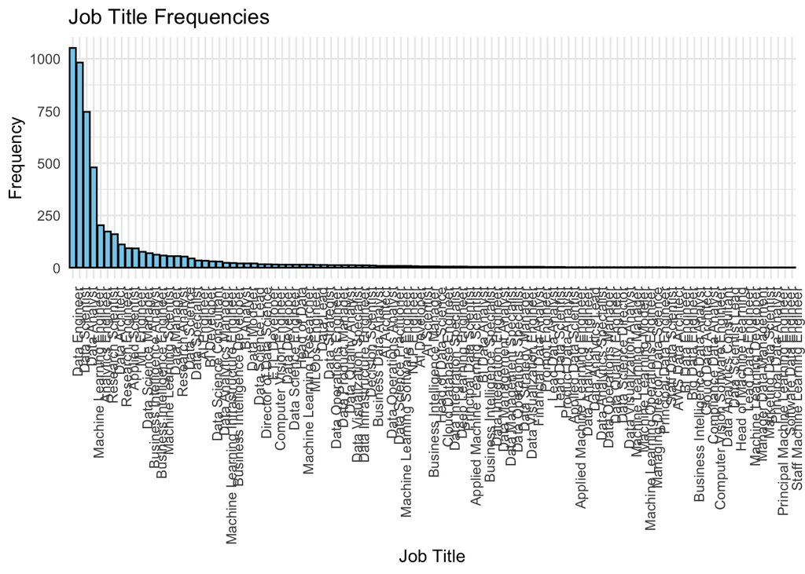

Rather than keeping job titles that appeared less than 20 times as separate titles, we aggregated them into “other” keyword.

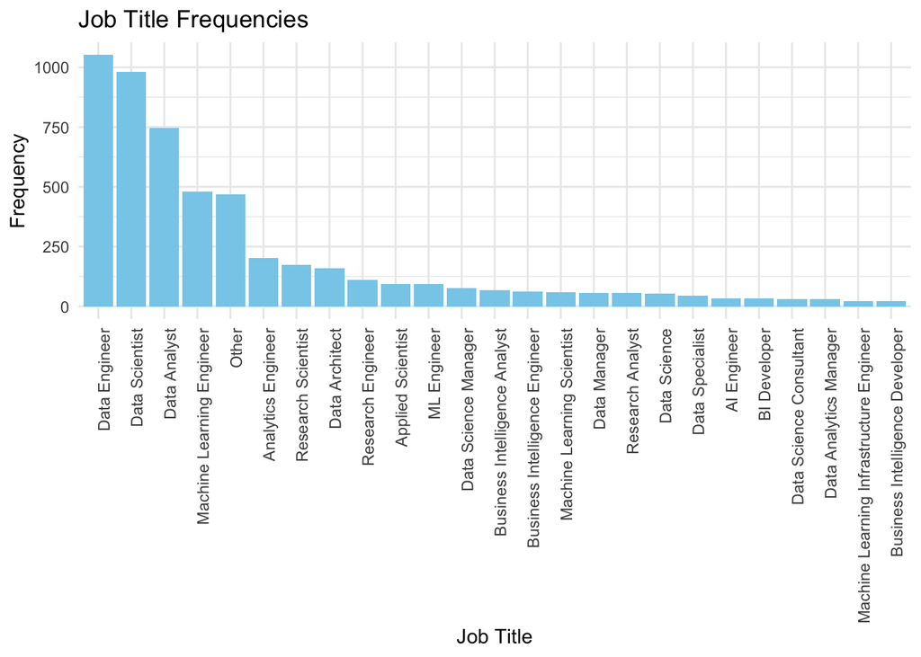

The above graph shows that job titles are right skewed.

```
## 'data.frame':    5204 obs. of  8 variables:
##  $ job_title       : chr  "Data Engineer" "Data Engineer" "Data Scientist" "Data Scientist" ...
##  $ experience_level: Factor w/ 4 levels "Entry-level",..: 2 2 3 3 2 2 1 1 4 4 ...
##  $ employment_type : chr  "Full-time" "Full-time" "Full-time" "Full-time" ...
##  $ work_models     : chr  "Remote" "Remote" "Remote" "Remote" ...
##  $ work_year       : int  2024 2024 2024 2024 2024 2024 2024 2024 2024 2024 ...
##  $ salary_in_usd   : int  148100 98700 140032 100022 120000 62100 250000 150000 219650 136000 ...
##  $ company_location: chr  "United States" "United States" "United States" "United States" ...
##  $ company_size    : chr  "Medium" "Medium" "Medium" "Medium" ...
```

=========================

## 3.4 Statistical Analysis and Hypothesis Testing

While EDA provides descriptive insights, statistical hypothesis testing is essential for assessing whether observed differences are statistically significant and not due to random chance. In this section, we applied normality tests, ANOVA, t-tests, and chi-squared tests.

### 3.4.1 Normality Testing: Shapiro-Wilk Tests

Before applying parametric tests, we tested for normality using the Shapiro-Wilk test.

We applied the Shapiro-Wilk test to various salary subsets: - **Full-time salaries** - **Part-time salaries** - **Contract salaries** - **Selected job titles (Data Scientist, Data Engineer, Data Analyst, etc.)**

```
##
##  Shapiro-Wilk normality test
##
## data:  full_time_sample$salary_in_usd
## W = 0.98061, p-value < 2.2e-16
```

```
##
##  Shapiro-Wilk normality test
##
## data:  part_time_data$salary_in_usd
## W = 0.91907, p-value = 0.4491
```

```
##
##  Shapiro-Wilk normality test
##
## data:  contract_data$salary_in_usd
## W = 0.86805, p-value = 0.1172
```

The results were as follows: - For **Full-time employees**, the p-value was less than 2.2e-16, indicating that the salary data deviates significantly from normality. - For **Part-time** and **Contract** employees, p-values were 0.4491 and 0.1172 respectively, suggesting approximate normality. - Among job titles, salaries for **Data Managers** and **Analytics Engineers** followed normal distributions, while others (e.g., Data Scientists, Research Analysts) did not.

```
##
##  Shapiro-Wilk normality test
##
## data:  data_manager$salary_in_usd
## W = 0.97033, p-value = 0.1905
```

```
##
##  Shapiro-Wilk normality test
##
## data:  research_analyst$salary_in_usd
## W = 0.90298, p-value = 0.0003165
```

```
##
##  Shapiro-Wilk normality test
##
## data:  data_engineer$salary_in_usd
## W = 0.97815, p-value = 1.745e-11
```

```
##
##  Shapiro-Wilk normality test
##
## data:  data_scientist$salary_in_usd
## W = 0.98507, p-value = 1.818e-08
```

```
##
##  Shapiro-Wilk normality test
##
## data:  data_analyst$salary_in_usd
## W = 0.96718, p-value = 6.878e-12
```

```
##
##  Shapiro-Wilk normality test
##
## data:  analytics_engineer$salary_in_usd
## W = 0.98744, p-value = 0.07004
```

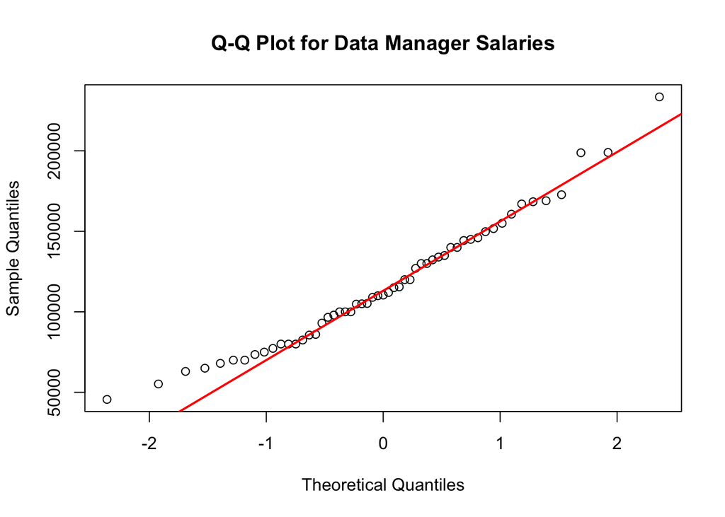

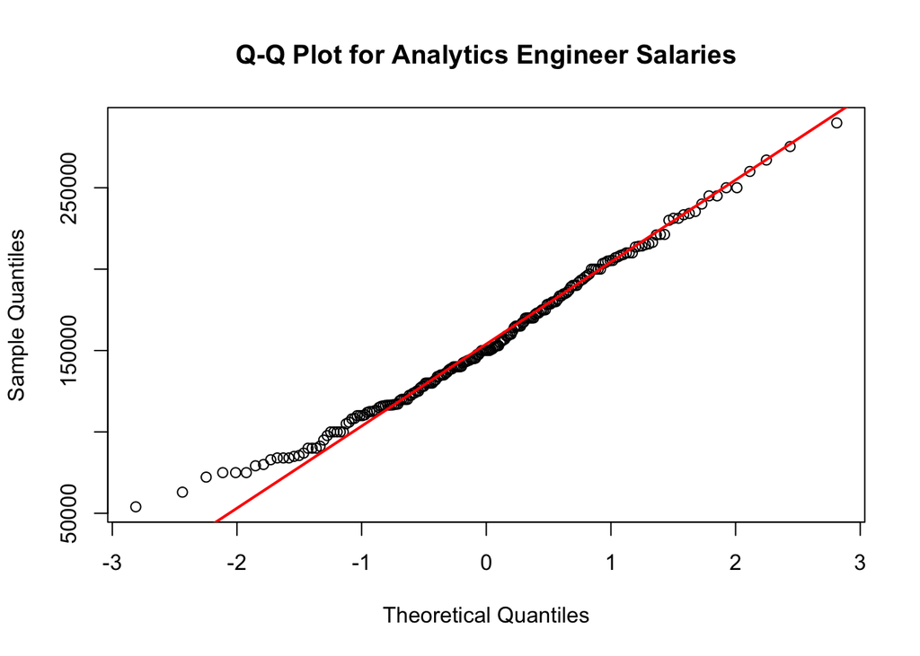

These findings guided our choice of statistical methods:  
- When normality held, we proceeded with t-tests. - When normality was violated, we interpreted parametric tests cautiously.

### 3.4.2 Group Comparisons: ANOVA Tests

### T-test

```r
t_test_result <- t.test(data_manager$salary_in_usd, analytics_engineer$salary_in_usd)

# Print the t-test result
print(t_test_result)
```

```
##
##  Welch Two Sample t-test
##
## data:  data_manager$salary_in_usd and analytics_engineer$salary_in_usd
## t = -6.1742, df = 97.927, p-value = 1.513e-08
## alternative hypothesis: true difference in means is not equal to 0
## 95 percent confidence interval:
##  -51096.20 -26239.23
## sample estimates:
## mean of x mean of y
##  116371.2  155038.9
```

```r
#Conduct shapiro test and t-test if applicable on work models column
unique(cleaned_salaries$work_models)
```

```
## [1] "Remote"  "On-site" "Hybrid"
```

```r
remote <- cleaned_salaries[cleaned_salaries$work_models == "Remote", ]
shapiro.test(remote$salary_in_usd)
```

```
##
##  Shapiro-Wilk normality test
##
## data:  remote$salary_in_usd
## W = 0.98781, p-value = 7.492e-12
```

```r
on_site_salaries <- cleaned_salaries[cleaned_salaries$work_models == "On-site", ]
shapiro.test(on_site_salaries$salary_in_usd)
```

```
##
##  Shapiro-Wilk normality test
##
## data:  on_site_salaries$salary_in_usd
## W = 0.97608, p-value < 2.2e-16
```

```r
hybrid <- cleaned_salaries[cleaned_salaries$work_models == "Hybrid", ]
shapiro.test(hybrid$salary_in_usd)
```

```
##
##  Shapiro-Wilk normality test
##
## data:  hybrid$salary_in_usd
## W = 0.94075, p-value = 0.03666
```

```r
cleaned_salaries
```

#### Salary by Work Year

We conducted an ANOVA test to assess whether salary means differed across years (2020–2024).

- F-statistic: 6.716
- p-value: 2.18e-05

Result:  
Rejecting the null hypothesis, we conclude that salaries differed significantly across years.

#### Salary by Experience Level

Another ANOVA test evaluated salary differences by experience level.

- F-statistic: 249.2
- p-value: < 2e-16

Result:  
Highly significant differences were found, confirming that experience plays a major role in salary determination.

#### Salary by Work Model

Examining Remote vs. Hybrid vs. On-site models:

- F-statistic: 4.969
- p-value: 0.00698

Result:  
We concluded that work model significantly influences salaries.

#### Salary by Company Size

Comparing Small, Medium, and Large companies:

- F-statistic: 8.18
- p-value: 0.000284

Result:  
Company size has a measurable, though smaller, effect on salary.

**Interpretation:**  
ANOVA tests consistently demonstrated that categorical factors such as experience level, work model, and company size have statistically significant effects on data scientist salaries.

### 3.4.3 Mean Comparisons: T-tests

To delve deeper into group differences, we conducted independent samples t-tests.

Example:  
Comparing **Data Manager** salaries vs **Analytics Engineer** salaries:

- p-value: 1.513e-08

Result:  
The p-value is much smaller than 0.05, leading us to reject the null hypothesis. There is strong evidence that average salaries differ between these two roles, with Analytics Engineers generally earning more.

This finding highlights the importance of role specialization and technical expertise in salary negotiation and career growth.

### 3.4.4 Association Testing: Chi-Squared Tests

```r
table_data <- table(cleaned_salaries$employment_type, cleaned_salaries$work_models)
chisq_test <- chisq.test(table_data)
cat("\n\n")
```

```r
cat("Chi-Squared Test for Employment Type and Work Models")
```

```
## Chi-Squared Test for Employment Type and Work Models
```

```r
print(chisq_test)
```

```
##
##  Pearson's Chi-squared test
##
## data:  table_data
## X-squared = 24.389, df = 4, p-value = 6.673e-05
```

```r
chisq_test$expected
```

```
##
##                  Hybrid     On-site      Remote
##   Contract   0.06917756    5.534204    3.396618
##   Full-time 39.90776326 3192.621061 1959.471176
##   Part-time  0.02305919    1.844735    1.132206
```

```r
table_data <- table(cleaned_salaries$company_size, cleaned_salaries$work_models)
chisq_test <- chisq.test(table_data)
cat("\n\n")
```

```r
cat("Chi-Squared Test for Company Size and Work Models")
```

```
## Chi-Squared Test for Company Size and Work Models
```

```r
print(chisq_test)
```

```
##
##  Pearson's Chi-squared test
##
## data:  table_data
## X-squared = 421.91, df = 4, p-value < 2.2e-16
```

```r
chisq_test$expected
```

```
##
##              Hybrid    On-site    Remote
##   Large   2.3904689  191.23751  117.3720
##   Medium 37.2252114 2978.01691 1827.7579
##   Small   0.3843198   30.74558   18.8701
```

```r
table_data <- table(cleaned_salaries$work_models, cleaned_salaries$experience_level)
chisq_test <- chisq.test(table_data)
cat("\n\n")
```

```r
cat("Chi-Squared Test for Experience Level and Work Models")
```

```
## Chi-Squared Test for Experience Level and Work Models
```

```r
print(chisq_test)
```

```
##
##  Pearson's Chi-squared test
##
## data:  table_data
## X-squared = 104.43, df = 6, p-value < 2.2e-16
```

```r
chisq_test$expected
```

```
##
##           Entry-level  Mid-level Senior-level Executive-level
##   Hybrid     2.774789   8.862414     26.81783        1.544965
##   On-site  221.983090 708.993082   2145.42659      123.597233
##   Remote   136.242121 435.144504   1316.75557       75.857802
```

```r
table_data <- table(cleaned_salaries$experience_level, cleaned_salaries$employment_type)
chisq_test <- chisq.test(table_data)
cat("\n\n")
```

```r
cat("Chi-Squared Test for Experience Level and Employment Type")
```

```
## Chi-Squared Test for Experience Level and Employment Type
```

```r
print(chisq_test)
```

```
##
##  Pearson's Chi-squared test
##
## data:  table_data
## X-squared = 50.918, df = 6, p-value = 3.076e-09
```

```r
chisq_test$expected
```

```
##
##                    Contract Full-time Part-time
##   Entry-level     0.6243274  360.1676 0.2081091
##   Mid-level       1.9940430 1150.3413 0.6646810
##   Senior-level    6.0340123 3480.9547 2.0113374
##   Executive-level 0.3476172  200.5365 0.1158724
```

We performed several chi-squared tests to explore associations between categorical variables:

| Test | Result |
| --- | --- |
| Employment Type vs. Work Model | Significant association (p = 6.673e-05) |
| Company Size vs. Work Model | Significant association (p < 2.2e-16) |
| Experience Level vs. Work Model | Significant association (p < 2.2e-16) |
| Experience Level vs. Employment Type | Significant association (p = 3.076e-09) |

Although chi-squared tests showed strong associations, we noted some cells had expected counts < 5, which can compromise reliability. Caution was applied when interpreting these results.

**Interpretation:**  
These findings suggest that employment type, work arrangement, and company size are interconnected. For example, executive-level employees may be more likely to hold remote or hybrid positions, while entry-level roles are more often on-site.

### **Summary of Statistical Testing Findings**

- Salary distributions are not fully normal, but robust methods were applied accordingly.
- Salaries vary significantly by year, experience level, work model, and company size.
- Specializations such as Analytics Engineering command higher salaries than general management roles.
- Work models, company sizes, and experience levels are associated with employment types in meaningful ways.

These statistical results justify the construction of predictive models that incorporate these influential factors.

==================================================

# **4. Data Preprocessing for Modeling (Final part)**

After completing data exploration and statistical testing, we built predictive models to estimate salaries and classify salary ranges. Two major modeling approaches were used:

- **Regression Models** for predicting continuous salary (`salary_in_usd`)
- **Classification Models** for categorizing salaries into income brackets Our goal was to evaluate model accuracy, performance, and reliability based on the available features.

We initially framed the problem as a regression task to predict the `salary_in_usd` directly based on input features such as:

- `job_title`
- `experience_level`
- `employment_type`
- `work_models`
- `company_size`
- `work_year`

## 4.1 Encoding

Before modeling, categorical variables were properly encoded as factors before modeling.

```
## 'data.frame':    5204 obs. of  8 variables:
##  $ job_title       : chr  "Data Engineer" "Data Engineer" "Data Scientist" "Data Scientist" ...
##  $ experience_level: Factor w/ 4 levels "Entry-level",..: 2 2 3 3 2 2 1 1 4 4 ...
##  $ employment_type : chr  "Full-time" "Full-time" "Full-time" "Full-time" ...
##  $ work_models     : chr  "Remote" "Remote" "Remote" "Remote" ...
##  $ work_year       : int  2024 2024 2024 2024 2024 2024 2024 2024 2024 2024 ...
##  $ salary_in_usd   : int  148100 98700 140032 100022 120000 62100 250000 150000 219650 136000 ...
##  $ company_location: chr  "United States" "United States" "United States" "United States" ...
##  $ company_size    : chr  "Medium" "Medium" "Medium" "Medium" ...
```

```
## 'data.frame':    5204 obs. of  7 variables:
##  $ job_title       : Factor w/ 25 levels "AI Engineer",..: 11 11 16 16 4 4 23 23 11 11 ...
##  $ experience_level: Factor w/ 4 levels "Entry-level",..: 2 2 3 3 2 2 1 1 4 4 ...
##  $ employment_type : Factor w/ 3 levels "Contract","Full-time",..: 2 2 2 2 2 2 2 2 2 2 ...
##  $ work_models     : Factor w/ 3 levels "Hybrid","On-site",..: 3 3 3 3 2 2 2 2 3 3 ...
##  $ work_year       : int  2024 2024 2024 2024 2024 2024 2024 2024 2024 2024 ...
##  $ salary_in_usd   : int  148100 98700 140032 100022 120000 62100 250000 150000 219650 136000 ...
##  $ company_size    : Factor w/ 3 levels "Large","Medium",..: 2 2 2 2 2 2 2 2 2 2 ...
```

## 4.2 Building Train/Test Dataset

# **5. Regression Models for Salary Prediction**

Three regression models were implemented and compared: ## 5.1 Linear Regression

```
##   Metric      Value
## 1   RMSE 52697.3175
## 2    MAE 42920.4273
## 3     R2     0.2576
## 4   MAPE    35.6495
```

We fitted an ordinary least squares (OLS) linear regression model as a baseline.

## 5.2 Random Forest Regression

Next, we applied a Random Forest regressor, an ensemble learning method that constructs multiple decision trees and outputs the mean prediction.

```
##  Random Forest Model Performance
```

```
## RMSE: 52227.05
```

```
## R²: 0.2346
```

```
## MAE: 42403.52
```

```
## MAPE: 34.38
```

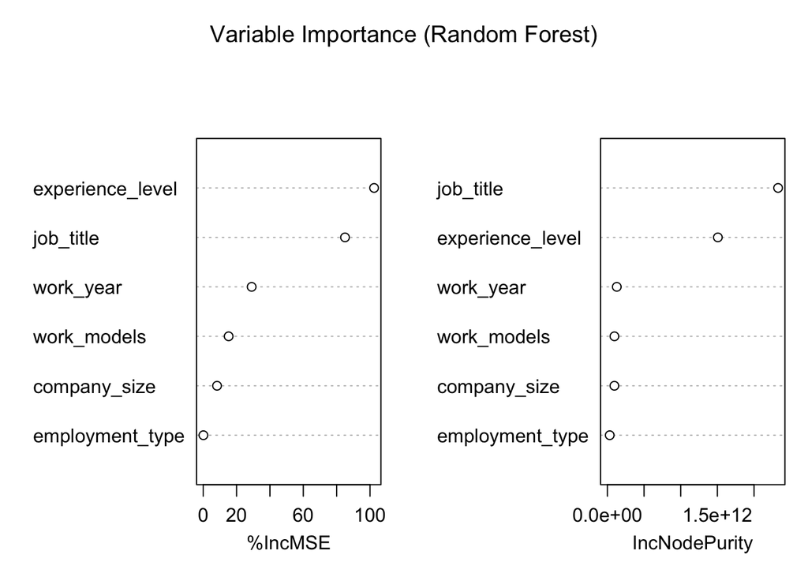

**Model Performance Evaluation** - **RMSE**: 52227.05 - **R²**: 0.2346 **Interpretation:** - Although Random Forest improved slightly in robustness (handling non-linearities and outliers better), it did not drastically outperform the linear model in terms of explained variance.

## 5.3 XGBoost Regression

Finally, we used XGBoost (Extreme Gradient Boosting), a high-performance boosting algorithm known for achieving strong results in tabular datasets.

```
##   Metric      Value
## 1   RMSE 52303.5391
## 2    MAE 42282.1287
## 3     R2     0.2299
## 4   MAPE    33.9818
```

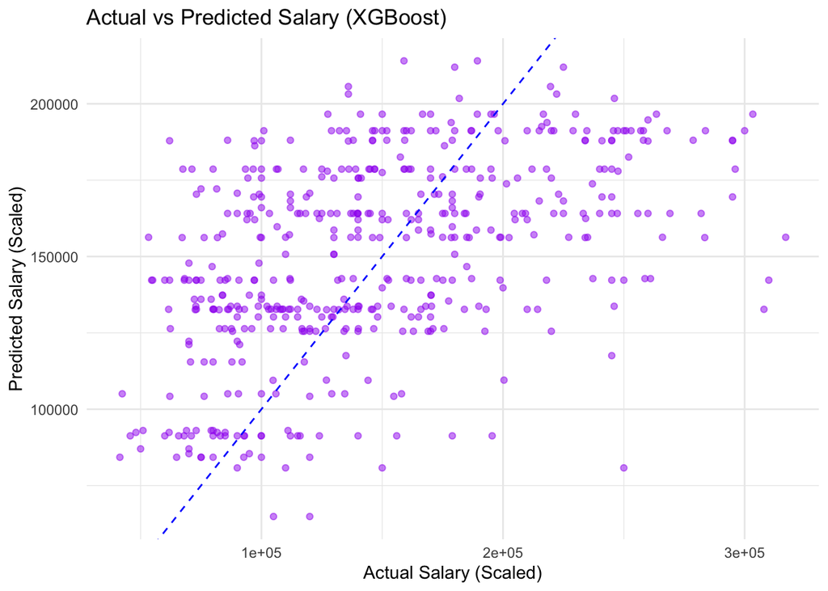

# **6.Classification Models for Income Categories**

## 6.1 Converting dataset to classfication

In addition to predicting continuous salaries, we categorized salaries into five income brackets based on the U.S. Bureau of Labor Statistics guidelines: - Lower than $30,000 - $30,000–$49,999 - $50,000–$74,999 - $75,000–$99,999 - $100,000 and above

```
##
##          Low income Lower-middle income       Middle income Upper-middle income
##                   4                  37                 344                 568
##         High income
##                4251
```

Delete low income group (<=30,000)

```
##
## Lower-middle income       Middle income Upper-middle income         High income
##                  37                 344                 568                4251
```

## 6.2 Building Train/Test Dataset

## 6.3 Multinomial Logistic Regression

```
## Confusion Matrix and Statistics
##
##                      Reference
## Prediction            Lower-middle income Middle income Upper-middle income
##   Lower-middle income                   0             0                   0
##   Middle income                         2             8                  14
##   Upper-middle income                   0             1                   1
##   High income                           2            29                  66
##                      Reference
## Prediction            High income
##   Lower-middle income           0
##   Middle income                17
##   Upper-middle income           0
##   High income                 347
##
## Overall Statistics
##
##                Accuracy : 0.731
##                  95% CI : (0.6893, 0.7699)
##     No Information Rate : 0.7474
##     P-Value [Acc > NIR] : 0.8128
##
##                   Kappa : 0.1359
##
##  Mcnemar's Test P-Value : NA
##
## Statistics by Class:
##
##                      Class: Lower-middle income Class: Middle income
## Sensitivity                            0.000000              0.21053
## Specificity                            1.000000              0.92650
## Pos Pred Value                              NaN              0.19512
## Neg Pred Value                         0.991786              0.93274
## Prevalence                             0.008214              0.07803
## Detection Rate                         0.000000              0.01643
## Detection Prevalence                   0.000000              0.08419
## Balanced Accuracy                      0.500000              0.56851
##                      Class: Upper-middle income Class: High income
## Sensitivity                            0.012346             0.9533
## Specificity                            0.997537             0.2114
## Pos Pred Value                         0.500000             0.7815
## Neg Pred Value                         0.835052             0.6047
## Prevalence                             0.166324             0.7474
## Detection Rate                         0.002053             0.7125
## Detection Prevalence                   0.004107             0.9117
## Balanced Accuracy                      0.504941             0.5823
```

```
##  Accuracy
## 0.7310062
```

- **Accuracy**: 0.731 **Interpretation:** Multinomial logistic regression offered understandable coefficients but performed weaker in accuracy compared to ensemble models.

## 6.4 Random Forest Classifier

```
## Confusion Matrix and Statistics
##
##                      Reference
## Prediction            Lower-middle income Middle income Upper-middle income
##   Lower-middle income                   0             0                   0
##   Middle income                         1             3                   4
##   Upper-middle income                   0             0                   0
##   High income                           3            35                  77
##                      Reference
## Prediction            High income
##   Lower-middle income           0
##   Middle income                 4
##   Upper-middle income           0
##   High income                 360
##
## Overall Statistics
##
##                Accuracy : 0.7454
##                  95% CI : (0.7042, 0.7835)
##     No Information Rate : 0.7474
##     P-Value [Acc > NIR] : 0.5655
##
##                   Kappa : 0.0537
##
##  Mcnemar's Test P-Value : NA
##
## Statistics by Class:
##
##                      Class: Lower-middle income Class: Middle income
## Sensitivity                            0.000000              0.07895
## Specificity                            1.000000              0.97996
## Pos Pred Value                              NaN              0.25000
## Neg Pred Value                         0.991786              0.92632
## Prevalence                             0.008214              0.07803
## Detection Rate                         0.000000              0.00616
## Detection Prevalence                   0.000000              0.02464
## Balanced Accuracy                      0.500000              0.52945
##                      Class: Upper-middle income Class: High income
## Sensitivity                              0.0000            0.98901
## Specificity                              1.0000            0.06504
## Pos Pred Value                              NaN            0.75789
## Neg Pred Value                           0.8337            0.66667
## Prevalence                               0.1663            0.74743
## Detection Rate                           0.0000            0.73922
## Detection Prevalence                     0.0000            0.97536
## Balanced Accuracy                        0.5000            0.52703
```

```
##  Accuracy
## 0.7453799
```

- **Accuracy**: 0.7454  
  **Interpretation:** Random Forest provided a moderate baseline classification accuracy but struggled to distinguish middle-income ranges precisely.

## 6.5 XGBoost Classifier

### 6.5.1 XGBoost Hyperparameter Tuning

**Hyperparameter tuning for XGBoost shows that the best parameters are:** - **nrounds:** 150 - **max_depth:** 6 - **eta:** 0.1 - **gamma:** 0 - **colsample_bytree:** 0.8 - **min_child_weight:** 1 - **subsample:** 0.8

The final XGBoost model is trained using these parameters.

### 6.5.2 Training XGBoost

```
## Confusion Matrix and Statistics
##
##                      Reference
## Prediction            Lower-middle income Middle income Upper-middle income
##   Lower-middle income                   0             0                   0
##   Middle income                         2             4                   7
##   Upper-middle income                   0             1                   1
##   High income                           2            33                  73
##                      Reference
## Prediction            High income
##   Lower-middle income           0
##   Middle income                 7
##   Upper-middle income           0
##   High income                 357
##
## Overall Statistics
##
##                Accuracy : 0.7433
##                  95% CI : (0.7021, 0.7816)
##     No Information Rate : 0.7474
##     P-Value [Acc > NIR] : 0.6059
##
##                   Kappa : 0.0912
##
##  Mcnemar's Test P-Value : NA
##
## Statistics by Class:
##
##                      Class: Lower-middle income Class: Middle income
## Sensitivity                            0.000000             0.105263
## Specificity                            1.000000             0.964365
## Pos Pred Value                              NaN             0.200000
## Neg Pred Value                         0.991786             0.927195
## Prevalence                             0.008214             0.078029
## Detection Rate                         0.000000             0.008214
## Detection Prevalence                   0.000000             0.041068
## Balanced Accuracy                      0.500000             0.534814
##                      Class: Upper-middle income Class: High income
## Sensitivity                            0.012346             0.9808
## Specificity                            0.997537             0.1220
## Pos Pred Value                         0.500000             0.7677
## Neg Pred Value                         0.835052             0.6818
## Prevalence                             0.166324             0.7474
## Detection Rate                         0.002053             0.7331
## Detection Prevalence                   0.004107             0.9548
## Balanced Accuracy                      0.504941             0.5514
```

```
## [1] "Accuracy: 0.743326488706366"
```

### 6.5.3 Importance of Variables

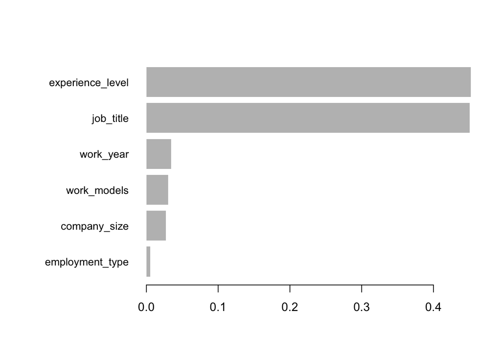

## 6.6 Naive Bayes Classifier

[output not shown]

```
## [1] "Accuracy: 0.731006160164271"
```

- **Accuracy**: 0.731 **Interpretation:** Naive Bayes underperformed due to strong independence assumptions that were unrealistic for salary features.

## 6.7 Support Vector Machine (SVM) Classifier

```
## [1] High income
## 4 Levels: Lower-middle income Middle income ... High income
```

```
## Confusion Matrix and Statistics
##
##                      Reference
## Prediction            Lower-middle income Middle income Upper-middle income
##   Lower-middle income                   0             0                   0
##   Middle income                         0             0                   0
##   Upper-middle income                   0             0                   0
##   High income                           4            38                  81
##                      Reference
## Prediction            High income
##   Lower-middle income           0
##   Middle income                 0
##   Upper-middle income           0
##   High income                 364
##
## Overall Statistics
##
##                Accuracy : 0.7474
##                  95% CI : (0.7064, 0.7854)
##     No Information Rate : 0.7474
##     P-Value [Acc > NIR] : 0.5242
##
##                   Kappa : 0
##
##  Mcnemar's Test P-Value : NA
##
## Statistics by Class:
##
##                      Class: Lower-middle income Class: Middle income
## Sensitivity                            0.000000              0.00000
## Specificity                            1.000000              1.00000
## Pos Pred Value                              NaN                  NaN
## Neg Pred Value                         0.991786              0.92197
## Prevalence                             0.008214              0.07803
## Detection Rate                         0.000000              0.00000
## Detection Prevalence                   0.000000              0.00000
## Balanced Accuracy                      0.500000              0.50000
##                      Class: Upper-middle income Class: High income
## Sensitivity                              0.0000             1.0000
## Specificity                              1.0000             0.0000
## Pos Pred Value                              NaN             0.7474
## Neg Pred Value                           0.8337                NaN
## Prevalence                               0.1663             0.7474
## Detection Rate                           0.0000             0.7474
## Detection Prevalence                     0.0000             1.0000
## Balanced Accuracy                        0.5000             0.5000
```

```
## [1] "Accuracy: 0.747433264887064"
```

- **Accuracy**: 0.7474 **Interpretation:** SVM achieved the highest classification accuracy among all tested models. SVMs are known for handling non-linear decision boundaries well, which likely contributed to their superior performance.

Thus, **SVM was selected as the best classifier** for income category prediction.

## 6.8 Predictions and Example Results

```
##                 Model  Accuracy
## 1                 SVC 0.7474333
## 2       Random Forest 0.7453799
## 4             XGBoost 0.7433265
## 3 Logistic Regression 0.7310062
## 5         Naive Bayes 0.7310062
```

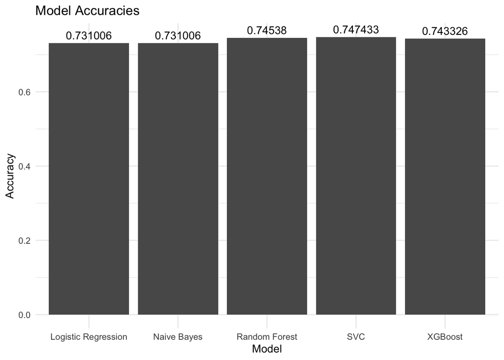

### **Classification Model Summary**

[output not shown]

**Results:**  
The SVC model was the best performer for predicting income categories.

# **7. Conclusion**

## **7.1 Predictive Modeling Insights**

This project extends the midterm analysis by integrating predictive modeling and classification techniques to provide a deeper understanding of salary trends in the data science field from 2020 to 2024. Through regression models, it became evident that predicting exact salary values remains challenging due to the complexity and variability of influencing factors. Ensemble methods like Random Forest and XGBoost offered slight improvements over linear models but still faced limitations in explanatory power.

In contrast, classification models demonstrated higher reliability when categorizing salaries into broader income ranges. Support Vector Classifiers(SVC) and Random Forest Classifiers, in particular, achieved the best performance, suggesting that advanced modeling techniques are well-suited to capturing salary tier patterns. The most influential factors across models were experience level and job title, reaffirming their critical roles in compensation decisions.

## **7.2 Limitations**

- **Feature Limitations:**  
  Important factors such as education, technical skills, certifications, and company reputation were not available in the dataset.
- **Moderate Variance Explanation:**  
  Even the best models left significant salary variability unexplained, suggesting the need for richer feature sets.
- **Self-Reported Data Bias:**  
  Potential biases in self-reported salary data may affect generalizability.

## **7.3 Recommendations for Future Work**

- Incorporate additional features such as educational background, technical certifications, skillsets, and company rankings.
- Explore advanced modeling techniques (e.g., stacking, deep learning) to improve predictive performance.
- Expand analysis to international datasets to compare global salary trends.
- Investigate longitudinal effects using time series or panel data approaches.

## **7.4 Final Thoughts**

These findings offer practical insights for both job seekers and employers: while precise salary predictions may be uncertain, identifying salary tiers based on candidate characteristics is a more attainable goal.

# **8. References**

1. Kaggle. (n.d.). *Data Science Salaries Dataset*. Retrieved from https://www.kaggle.com/datasets/ruchi798/data-science-job-salaries
2. U.S. Bureau of Labor Statistics. (2022). *Occupational Outlook Handbook: Data Scientists*. Retrieved from https://www.bls.gov/ooh/math/data-scientists.htm
3. Wickham, H. (2016). *ggplot2: Elegant Graphics for Data Analysis*. Springer-Verlag New York.
4. Kuhn, M., & Johnson, K. (2013). *Applied Predictive Modeling*. Springer.
5. Chen, T., & Guestrin, C. (2016). *XGBoost: A Scalable Tree Boosting System*. Proceedings of the 22nd ACM SIGKDD International Conference on Knowledge Discovery and Data Mining.